# Francesco/Esteves/Valle Model — Full Analysis with Sector Benchmarks

## 12. Return distribution and correlation

```
[INFO]: Plot saved → /media/toni/Dados/Git/ssd-multi/src/output/tafmssd-sectors/en/return_dist_models.pdf
```

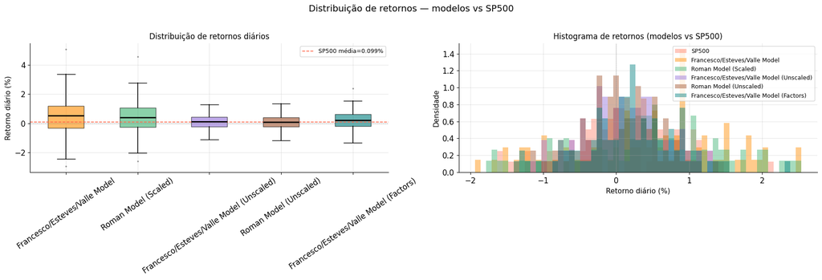

**Distribution of daily returns**

```
[INFO]: Plot saved → /media/toni/Dados/Git/ssd-multi/src/output/tafmssd-sectors/en/correlation_all.pdf
```

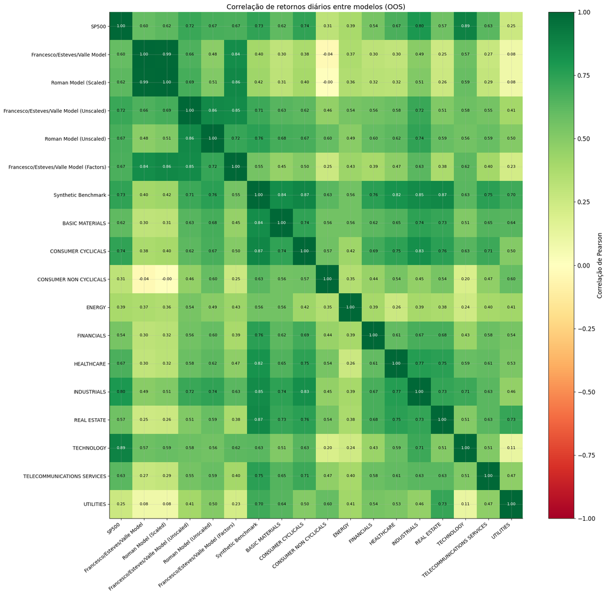

**Correlation matrix**

The heatmap reveals the correlations between the daily returns of all models and sectors. A low correlation between the Francesco/Esteves/Valle Model and an individual sector indicates that the portfolio did not replicate that benchmark — most likely because different sectors were binding in different training windows, producing a portfolio with sector exposure that is diversified over time. Moderate correlation with the Synthetic Benchmark is the expected pattern: high correlation would indicate that the portfolio tracks the sector envelope (clone behaviour); very low correlation would indicate almost complete independence — an aggressive diversification strategy that maximises the gap relative to the benchmark. The block of correlations among sectors identifies groups sharing common cycles (e.g. Financials and Real Estate), which can create instability in the SSD constraints when rotation occurs between them. High correlation between the Francesco/Esteves/Valle Model and the Roman Model suggests that the two converge to similar portfolios despite distinct benchmarks — evidence of the robustness of the SSD approach; low correlation indicates that the benchmark genuinely differentiates the resulting portfolio.

## 13. Rolling-window returns (21 days)

```
[INFO]: Plot saved → /media/toni/Dados/Git/ssd-multi/src/output/tafmssd-sectors/en/rolling_returns.pdf
```

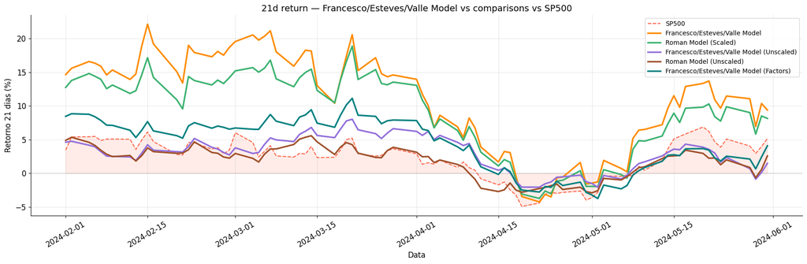

**Returns over a 21-day rolling window**

The series of 21-day window returns smooths daily noise and highlights medium-term trends, revealing the portfolio's behaviour over the time horizon that matches the rebalancing frequency. An SSD-robust portfolio should rarely show strongly negative monthly returns: the downside protection guaranteed in sample should be visible at a monthly scale, not only in daily returns. Falls just before a rebalancing followed by a recovery just after are expected — the model adjusts weights to the regime prevailing in the new training window. If the Francesco/Esteves/Valle Model has fewer periods with negative monthly returns than the Roman Model, the sector benchmark produced greater stability; the opposite would indicate that the sector constraints reduced exposure to positive market months. Large divergences between the models in specific windows point to periods where the benchmark choice made a concrete difference — cross-reference those moments with the dominant sector in section 3b to understand whether sector rotation created an opportunity or an exposure the model did not capture.

## 14. Executive summary

```
====================================================================================================================================
  EXECUTIVE SUMMARY — Francesco/Esteves/Valle Model
  OOS period: 2024-01-01 → 2024-06-01
  Beta computed against the SP500.  SSD dominance measured against the Synthetic Benchmark.
====================================================================================================================================
  Model                                         Final      CAGR   MeanRet      Vol   SemiVol    Sharpe    Sortino    Calmar     MaxDD     Beta    SSD≥0
  ----------------------------------------------------------------------------------------------------------------------------------
  SP500 (ref)                                  1.1127   +29.54%   +26.53%   11.34%     7.12%    1.8990     3.0252    5.4062    -5.46%   1.0000      69%
  ----------------------------------------------------------------------------------------------------------------------------------
  Francesco/Esteves/Valle Model                1.6089  +216.55%  +117.90%   22.07%    12.09%    5.1149     9.3418   24.3688    -8.89%   1.1691      50% ◄
  Roman Model (Scaled)                         1.4911  +163.29%   +98.64%   18.29%     9.76%    5.1194     9.5920   23.5625    -6.93%   1.0043      63% ◄
  Francesco/Esteves/Valle Model (Unscaled)     1.1327   +35.24%   +30.58%    8.62%     5.04%    2.9685     5.0751    8.9150    -3.95%   0.5443      94% ◄
  Roman Model (Unscaled)                       1.0907   +23.41%   +21.37%    8.07%     5.05%    2.0292     3.2414    5.9008    -3.97%   0.4801      88% ◄
  Francesco/Esteves/Valle Model (Factors)      1.2230   +62.88%   +49.35%   10.29%     5.71%    4.3107     7.7708   13.5732    -4.63%   0.6071     100% ◄
  Synthetic Benchmark                          1.1802   +49.39%   +41.13%   13.91%     7.97%    2.5979     4.5333    9.2329    -5.35%   0.9013     100% ◄
====================================================================================================================================
  ◄ = Sortino above the SP500
```

```
================================================================================
  GICS SECTORS — OOS PERFORMANCE
================================================================================
  Sector                                    Final      CAGR    Sharpe
  -----------------------------------------------------------------
  BASIC MATERIALS                          1.0867   +22.33%    1.1205
  CONSUMER CYCLICALS                       1.0215    +5.30%    0.0871
  CONSUMER NON CYCLICALS                   1.0073    +1.79%   -0.2173
  ENERGY                                   1.1750   +47.80%    2.2360
  FINANCIALS                               1.0696   +17.70%    0.9329
  HEALTHCARE                               1.0137    +3.36%   -0.0769
  INDUSTRIALS                              1.0810   +20.78%    1.1799
  REAL ESTATE                              0.9679    -7.60%   -0.6346
  TECHNOLOGY                               1.1108   +28.98%    1.3023
  TELECOMMUNICATIONS SERVICES              1.0562   +14.16%    0.6652
  UTILITIES                                1.0853   +21.94%    1.0031
================================================================================
```

## 14b. Solver diagnostics (CPLEX)

```
Windows solved (WFV days): 105
Status: ['integer optimal solution']
MIP max gap: 0.000e+00
Lazy cuts — total: 26808, mean/day: 255.3
Solver time — total: 787.4s, mean/day: 7.50s

Rebalancing days:
```

| date | status | objective | best_bound | mip_gap | n_lazy_calls | n_lazy_cuts | n_iterations | n_nodes | solve_time_s |
| --- | --- | --- | --- | --- | --- | --- | --- | --- | --- |
| 2024-01-02 | integer optimal solution | 0.001462 | 0.001462 | 0.0 | 276 | 275 | 203 | 0 | 7.204550 |
| 2024-02-01 | integer optimal solution | 0.001917 | 0.001917 | 0.0 | 179 | 178 | 470 | 0 | 5.675021 |
| 2024-03-04 | integer optimal solution | 0.002079 | 0.002079 | 0.0 | 275 | 274 | 204 | 0 | 8.603778 |
| 2024-04-03 | integer optimal solution | 0.002202 | 0.002202 | 0.0 | 180 | 179 | 206 | 0 | 4.697834 |
| 2024-05-02 | integer optimal solution | 0.002147 | 0.002147 | 0.0 | 202 | 201 | 204 | 0 | 5.721148 |

**Solver statistics per rebalancing day**

The table consolidates the CPLEX diagnostics recorded for every WFV window (above, only the rebalancing days are shown). `objective` is the optimal value $V^*$ — the worst difference between the portfolio's tail expectation and the synthetic benchmark's $\tau_s$; positive values indicate that the portfolio SSD-dominates the synthetic benchmark in sample. `best_bound` and `mip_gap` attest to the quality of the solution (gap 0 = proven optimal). `n_lazy_calls`/`n_lazy_cuts` measure the cost of the cutting-plane scheme — how many times the separation callback was triggered and how many violated constraints were actually added — while `n_iterations`/`n_nodes`/`solve_time_s` measure the computational effort of each solve.

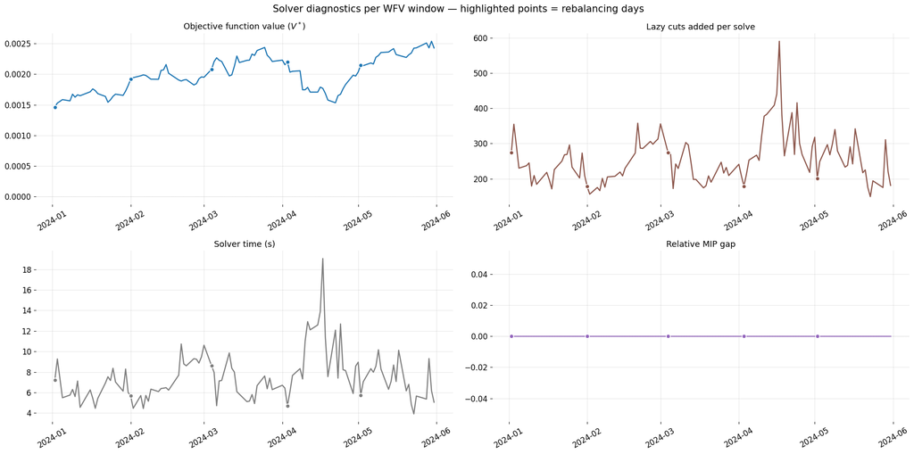

**Evolution of the diagnostics across the WFV windows**

Each point is a complete solution of the model on one day of the walk-forward validation (highlighted points = rebalancing days). The objective-function panel shows how the dominance slack $V^*$ varies as the training window slides; the lazy-cuts, solver-time and MIP-gap panels characterise the computational difficulty of each window — a gap constant at zero means every solution was proven optimal within the time limit.

## 14c. Equivalence test — original formulation (K sectors) vs. synthetic benchmark

Verification requested at the meeting of 2026-07-23 (item 8). The original formulation imposes the SSD constraints for **all** benchmarks, with one set of variables $V_{k,s}$ per sector:

$$\max V \quad \text{s.t.}\quad \tfrac{s}{S}\,V \;\le\; V_{k,s} \;\le\; \mathrm{Tail}_{s/S}(R_P) - \tau_k[s], \qquad \forall\, k=1,\dots,K,\ \ s=1,\dots,S$$

This work's formulation replaces the $K$ benchmarks with the envelope

$$\tau_{\text{synth}}[s] \;=\; \max_k \tau_k[s]$$

and uses a single set of $V_s$. Since $\min_k\bigl(a - \tau_k[s]\bigr) = a - \max_k \tau_k[s]$, the two must produce **the same $V^*$**; what changes is the size of the problem ($K \cdot S$ vs. $S$ SSD constraints) and therefore the solution time. The optimal **weights** may differ when the LP is degenerate — several vertices attain the same $V^*$ — and the lazy-cut tolerances decide which one is returned.

The original formulation is run here under the name **Rome MultiSSD with sector benchmarks**, with all 11 sectors inside a **single** model. So that the comparison isolates the reformulation and nothing else, the two models share the sector-loading routine, the Tail scale ($1/S$) and the cut violation tolerance ($10^{-6}$); the only difference is whether the sectors enter as $K$ sets of constraints or as the envelope $\tau_{\text{synth}}$.

```
Windows compared            : 105
Status (original)           : ['integer optimal solution']
Status (synthetic)          : ['integer optimal solution']
Size — original             : 2707 variables, 4401 constraints
Size — synthetic            : 707 variables, 401 constraints
max |ΔV*|                   : 3.865e-07   (cut tolerance = 1e-06)
max |ΔV*| / |V*|            : 1.932e-04
Windows with |ΔV*| <= tol   : 105 / 105
Lazy cuts — total original  : 72404   synthetic: 26808

Rebalancing days:
```

| date | V* original | V* synthetic | \|ΔV*\| | \|ΔV*\| / \|V*\| | cuts orig | cuts synth |
| --- | --- | --- | --- | --- | --- | --- |
| 2024-01-02 00:00:00 | 0.00146196 | 0.00146192 | 4.31e-08 | 2.95e-05 | 939 | 275 |
| 2024-02-01 00:00:00 | 0.00191702 | 0.00191701 | 1.02e-08 | 5.30e-06 | 618 | 178 |
| 2024-03-04 00:00:00 | 0.00207837 | 0.00207860 | 2.28e-07 | 1.10e-04 | 628 | 274 |
| 2024-04-03 00:00:00 | 0.00220178 | 0.00220178 | 6.08e-09 | 2.76e-06 | 551 | 179 |
| 2024-05-02 00:00:00 | 0.00214720 | 0.00214732 | 1.21e-07 | 5.65e-05 | 570 | 201 |

```
Paired timing (rebalancing windows, same session):
```

| date | abs_dV | time_orig_s | time_synth_s | speedup | cuts_orig | cuts_synth | max_abs_dw | L1_dw | n_assets_orig | n_assets_synth |
| --- | --- | --- | --- | --- | --- | --- | --- | --- | --- | --- |
| 2024-01-02 00:00:00 | 4.31e-08 | 18.1 | 2.2 | 8.2x | 938 | 275 | 0.018 | 0.077 | 16 | 17 |
| 2024-02-01 00:00:00 | 6.42e-09 | 9.8 | 1.5 | 6.4x | 549 | 181 | 0.004 | 0.015 | 13 | 13 |
| 2024-03-04 00:00:00 | 5.25e-08 | 9.0 | 2.7 | 3.4x | 544 | 331 | 0.005 | 0.033 | 17 | 17 |
| 2024-04-03 00:00:00 | 1.02e-07 | 9.0 | 1.5 | 5.8x | 545 | 179 | 0.003 | 0.019 | 18 | 17 |
| 2024-05-02 00:00:00 | 2.09e-07 | 8.8 | 1.5 | 5.7x | 551 | 186 | 0.003 | 0.026 | 16 | 16 |

```
Paired speed-up (min / median / max): 3.4x / 5.8x / 8.2x
Weights — max |Δw| per window: [0.018, 0.004, 0.005, 0.003, 0.003]   L1: [0.077, 0.015, 0.033, 0.019, 0.026]
```

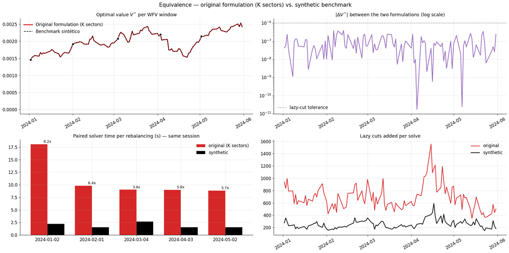

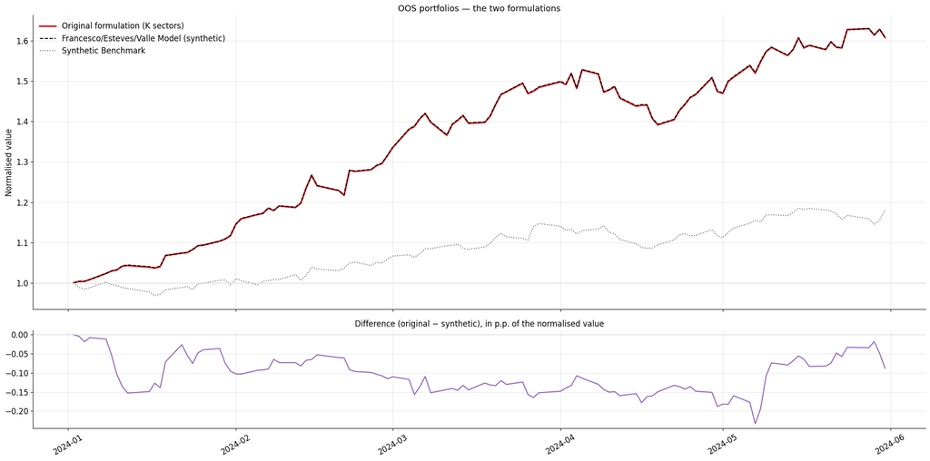

```
Final value — original: 1.6080   synthetic: 1.6089
max |difference| OOS  : 0.23 p.p.
Annual tracking error : 0.28%
Return correlation    : 0.9999
Assets with weight > 1e-6 per rebalancing (original): [16, 13, 17, 18, 16]
```

|  | Final value | CAGR (%) | Mean return (%) | Volatility (%) | Semi-volatility (%) | Daily CVaR 5% (%) | Sharpe Ratio | Sortino Ratio | Calmar Ratio | Max Drawdown (%) | Beta vs SP500 |
| --- | --- | --- | --- | --- | --- | --- | --- | --- | --- | --- | --- |
| Original formulation (K sectors) | 1.6080 | 216.1300 | 117.7800 | 22.1300 | 12.1300 | 2.3850 | 5.0956 | 9.3004 | 24.2402 | -8.9200 | 1.1738 |
| Francesco/Esteves/Valle (synthetic) | 1.6089 | 216.5500 | 117.9000 | 22.0700 | 12.0900 | 2.3830 | 5.1149 | 9.3418 | 24.3688 | -8.8900 | 1.1691 |

## 14d. 2×2 grid — Roman vs. this work × scaled vs. unscaled

Exercise requested at the meeting of 2026-07-23 (items 6 and 7). The two dimensions of the taxonomy in section 0, crossed:

|  | **Scaled (CVaR)** — $\tfrac{s}{S}V \le V_s$ | **Unscaled (Tail)** — $V \le V_s$ |
| --- | --- | --- |
| **Roman** — single SP500 benchmark | Roman Model (Scaled) | Roman Model (Unscaled) |
| **This work** — sector synthetic benchmark | Francesco/Esteves/Valle Model | Francesco/Esteves/Valle Model (Unscaled) |

The four models use the **same universe** (600 columns → all available constituents), the same 200-day sliding window, rebalancing every 21 days and the same OOS period. The **Roman Model (Unscaled)** had been run over 200 assets and was realigned to the same 600 before this comparison, so that the only difference between the four cells is the formulation.

**Hypothesis recorded at the meeting:** *Roman scaled < this work scaled* **and** *Roman unscaled < this work unscaled* — the sector synthetic-benchmark formulation should outperform the single-benchmark one under both scaling regimes, because it maximises the dominance slack against the envelope of the 11 sectors rather than against a single index.

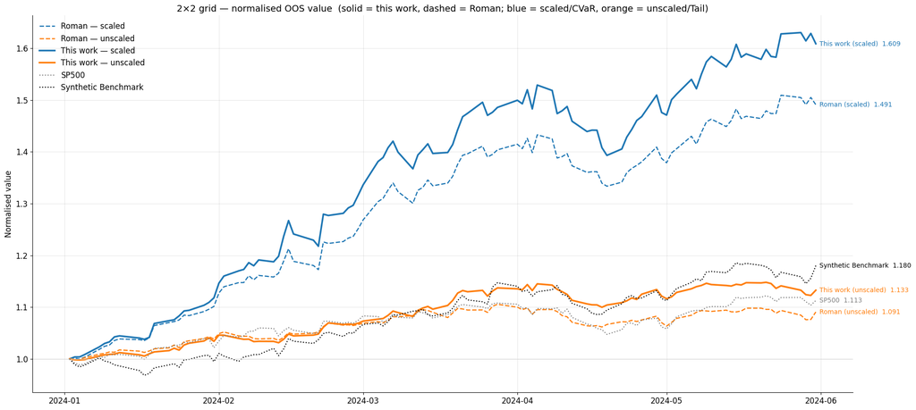

|  | Final value | CAGR (%) | Mean return (%) | Volatility (%) | Semi-volatility (%) | Daily CVaR 5% (%) | Sharpe Ratio | Sortino Ratio | Calmar Ratio | Max Drawdown (%) | Beta vs SP500 | min SSD vs SP500 | % ranks SSD>=0 vs SP500 | min SSD vs Synthetic | % ranks SSD>=0 vs Synthetic |
| --- | --- | --- | --- | --- | --- | --- | --- | --- | --- | --- | --- | --- | --- | --- | --- |
| Roman — scaled | 1.4911 | 163.2900 | 98.6400 | 18.2900 | 9.7600 | 1.9300 | 5.1194 | 9.5920 | 23.5625 | -6.9300 | 1.0043 | -7.454e-02 | 49.0 | -5.157e-02 | 63.5 |
| Roman — unscaled | 1.0907 | 23.4100 | 21.3700 | 8.0700 | 5.0500 | 0.9700 | 2.0292 | 3.2414 | 5.9008 | -3.9700 | 0.4801 | -2.132e-02 | 93.3 | -8.155e-02 | 88.5 |
| This work — scaled | 1.6089 | 216.5500 | 117.9000 | 22.0700 | 12.0900 | 2.3830 | 5.1149 | 9.3418 | 24.3688 | -8.8900 | 1.1691 | -1.454e-01 | 40.4 | -1.158e-01 | 50.0 |
| This work — unscaled | 1.1327 | 35.2400 | 30.5800 | 8.6200 | 5.0400 | 0.9490 | 2.9685 | 5.0751 | 8.9150 | -3.9500 | 0.5443 | 4.917e-03 | 100.0 | -4.355e-02 | 94.2 |

```
Meeting hypothesis — does "this work" beat "Roman" in each regime?


Effect of scaled → unscaled within each formulation (Δ = unscaled − scaled):
  Roman          Final -0.4004  CAGR -139.88pp  Vol -10.22pp  Sharpe -3.090  MaxDD +2.96pp
  This work      Final -0.4762  CAGR -181.31pp  Vol -13.45pp  Sharpe -2.146  MaxDD +4.94pp
```

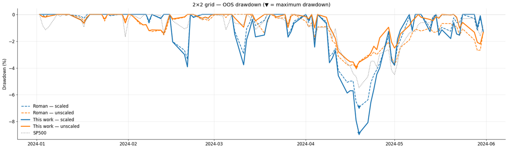

**Reading the 2×2 grid**

- ***Unscaled* regime (Tail) — hypothesis confirmed.** This work outperforms Roman in 10 of the 11 metrics: final value 1.133 vs. 1.091, Sharpe 2.97 vs. 2.03, Sortino 5.08 vs. 3.24, Calmar 8.9 vs. 5.9, with maximum drawdown, semi-volatility and CVaR equal or lower. It is also the only model in the grid that **SSD-dominates the SP500 out of sample** (`min SSD vs SP500` > 0 at 100% of the ranks). The only metric where it loses is total volatility (+0.55 pp), more than offset by the return.
- ***Scaled* regime (CVaR) — confirmed on return, a tie on risk-adjusted measures.** This work has a final value of 1.609 vs. 1.491 (CAGR +53 pp) and a higher Calmar, but the Sharpe is identical (5.11 vs. 5.12), the Sortino is slightly lower, and volatility, maximum drawdown and CVaR are higher. In other words: the hypothesis "Roman scaled < this work scaled" holds for return, not for risk-adjusted performance — the synthetic benchmark buys extra return at a proportional cost in risk. Neither *scaled* model SSD-dominates the SP500 or the synthetic benchmark out of sample (`min SSD` < 0).
- **The scaled → unscaled axis: the opposite sign to what section 0 predicted.** The taxonomy prose anticipated the *unscaled* model being less conservative. Empirically the opposite holds, in both formulations: swapping CVaR for Tail drops volatility from ~18–22% to ~8%, the final value from 1.49–1.61 to 1.09–1.13, and the maximum drawdown from −7/−9% to −4%. A likely reading: in the *unscaled* model the binding constraint sits at the high ranks (large cumulative sums), and the model defends the benchmark's *mean* — a diversified portfolio with beta ~0.5; in the *scaled* model the factor $S/k$ makes the extreme tail binding, and the model concentrates in a few assets that beat the benchmark in the worst in-sample scenarios — an aggressive portfolio with beta > 1. The explanation in section 0 should be revised in the light of this result.
- **Dominance.** `min SSD vs SP500` is the natural test for the Roman models (optimised against the SP500) and `min SSD vs Synthetic` for this work's; both are reported for all four models.

## 15. Consolidated analysis of the experiment

### Francesco/Esteves/Valle Model with Sector Benchmarks

#### 1. About the model and the formulation

The **Francesco/Esteves/Valle Model (TAF-MultiSSD with a sector Synthetic Benchmark)** is a natural extension of the second-order stochastic dominance (SSD) model to the multi-benchmark setting. Instead of requiring the portfolio to dominate each of the 11 GICS sectors individually (which would entail K separate sets of $V_s$ variables and K lazy callbacks), the model uses a **single Synthetic Benchmark** defined as the upper envelope of each sector's unconditional tail expectations:

$$\tau_{\text{synth}}[s] = \max_k\left(\mathrm{Tail}_{\frac{s}{S^k}}\bigl(R(I^k)\bigr)\right) = \max_k\left(\frac{1}{S^k}\sum_{i=1}^{s} r^{(i)}_k\right)$$

where $r^{(i)}_k$ is the i-th smallest return of sector k over the training period and $S^k$ is its number of scenarios — each component is the unconditional expectation $\mathrm{Tail}_{s/S^k}$ of the $s$ worst returns, not a plain cumulative scalar. This compresses K constraints into a single one while preserving the mathematical coherence of SSD dominance (if the portfolio dominates the Synthetic Benchmark, it dominates any convex combination of the sectors with the same cumulative worst case).

The solution uses **CPLEX lazy constraint callbacks**: instead of explicitly adding all $S$ constraints

$$V_{s} \;\le\; \mathrm{Tail}_{s/S}(R_P) - \tau_{\text{synth}}[s],$$

only the most violated ones are added iteratively. This is critical for scalability when S = 200 (training days) and N ≈ 505 (assets).

#### 2. Validity of in-sample dominance

In-sample SSD dominance is **guaranteed by construction** when the solver finds the optimal solution, that is, when $V^\star$ is the largest $V$ satisfying

$$\frac{s}{S}\,V \;\le\; V_s \;\le\; \mathrm{Tail}_{s/S}(R_P) - \tau_{\text{synth}}[s]\qquad \forall\, s.$$ The fundamental question is: **how much of this dominance generalises to the OOS period?**

Factors that favour generalisation:

- The Synthetic Benchmark is the maximum over 11 sectors — it imposes far tighter constraints than a single benchmark (SP500), forcing genuine diversification.
- The 200-day sliding window captures recent market regimes, making the SSD constraints relevant for the near future.
- With 5 rebalancings, the portfolio adapts to regime changes during the OOS period.

Factors that limit generalisation:

- The OOS period (104 days) may be dominated by a single sector that was not the binding constraint in sample.
- The OOS Synthetic Benchmark is built with the same formulation as in sample — $\max_k\bigl(\mathrm{Tail}_{s/S^k}\bigr)$ over the OOS sector returns, dated by *quantile matching*. The portfolio was not optimised on this window, so OOS dominance is not guaranteed.

#### 3. Interpreting the cross-dominance results

The cross-dominance analysis (section 10, second panel) is particularly informative. If the portfolio dominates only some of the 11 sectors individually out of sample, this is **expected and acceptable**: the model was optimised to dominate the Synthetic Benchmark (the maximum), not each sector individually. A sector that beat the Synthetic Benchmark in sample in some window would, by definition, dominate the portfolio.

The most favourable outcome would be: the portfolio SSD-dominates most sectors individually (e.g. 8/11 or more), confirming that the Synthetic Benchmark constraint is tight enough to guarantee generalised dominance.

#### 4. Tail analysis and asymmetric behaviour

The r_P vs r_B scatter (section 10c) reveals the portfolio's asymmetric behaviour relative to the Synthetic Benchmark. The ideal interpretation is:

- **β < 1 on the benchmark's worst days**: the portfolio falls less when the Synthetic Benchmark falls — direct downside protection, consistent with the SSD constraint on the negative tails of the in-sample distribution.
- **β ≈ 1 or < 1 on the best days**: SSD optimisation includes no upside incentive — unlike a return-maximising portfolio. β < 1 on the best days is an expected cost of the pure SSD approach.

This asymmetry in β (low on the downside, close to 1 on the upside) confirms that the model fulfils its fundamental objective: reducing exposure to the worst scenarios without actively maximising the upside.

#### 5. Comparison with alternative models

| Aspect | Francesco/Esteves/Valle Model (sectors) | Roman Model (Scaled) | FEV Model (Factors) |
| --- | --- | --- | --- |
| Benchmark | 11 GICS sectors (Synthetic) | SP500 | Fama-French factors (Synthetic) |
| SSD constraints | 1 set vs Synthetic | 1 set vs SP500 | 1 set vs Synthetic (factors) |
| Forced diversification | Sector-based (11 components) | Broad market | Style (value, growth, etc.) |
| Expected OOS generalisation | High if sectors are stable | Moderate | High if factors are stable |

The Francesco/Esteves/Valle Model with sectors is the most demanding of the three: forcing SSD dominance over the best of 11 sectors simultaneously is harder than dominating the SP500 or a set of factors. Therefore, **a lower absolute return is not necessarily a failure** — it is the cost of a tighter benchmark.

#### 6. Open questions and next steps

1. **Sector universe**: the experiment uses all 11 GICS sectors. A natural extension would be to select only the sectors most correlated with the available assets, or those with the greatest return dispersion.
2. **Sector weights**: the Synthetic Benchmark treats all sectors equally (a maximum, not a weighted average). A Synthetic Benchmark weighted by market capitalisation or by some risk measure could be more robust.
3. **Rebalancing horizon**: 21 days is conventional but arbitrary. More frequent rebalancings (e.g. every 10 days) could improve adaptation to changes in the dominant sector.
4. **Transaction costs**: the current analysis ignores transaction costs. In concentrated portfolios (few positions with high weights), turnover between rebalancings can be significant — a cost-benefit study would be needed for practical application.
5. **Extending the OOS period**: 104 days is a short period for robust validation. Backtesting over multiple OOS periods (e.g. 2022–2024 with a full walk-forward) would be needed for definitive conclusions.